# ML ASS 1 LR CVD PREDICTION NEW

KIBIDI

2026-04-19

## R Markdown

Course: PROFFESIONAL CERTIFICATE IN DATA ANALYSIS, MACHINE LEARNING AND AI Instructor: Lumumba W. Victor Email: lumumbavictor172@gmail.com

student: KIBIDI LERENCER Reg no: CDAM/0047/2026 Email: kabeyi24leren@gmail.com

Date Issued: April , 2026

```r
 setwd("C:/Users/h6p/Desktop/ASSIGNMENTS")
```

3.1 Task 1: Data Import and Exploration (10 Marks)

#3.1.1. Load all necessary libraries

```r
library(tidyverse)# Data manipulation
library(caret)# Unified ML interface
library(pROC)# ROC analysis
library(e1071)# SVM
library(class)# KNN
library(randomForest) # Random Forest
library(dplyr)
```

#3.1.2. Import the dataset medical_data.csv.

```r
pressure <- read_csv("medical_data.csv")
head(pressure)
```

```
## # A tibble: 6 × 16
##     age gender   bmi blood_pressure cholesterol glucose smoking alcohol
##   <dbl>  <dbl> <dbl>          <dbl>       <dbl>   <dbl>   <dbl>   <dbl>
## 1  36.6      0  19.9           127.        207.   106.        1       0
## 2  41.5      1  32.1           126.        144.    76.9       1       1
## 3  68.4      1  30.4           105.        156.   102.        1       0
## 4  46.1      1  25.5           140.        257.   131.        0       0
## 5  46.9      0  26.9           108.        139.    58.7       0       0
## 6  70.7      0  29.4           135.        285.    78.2       0       0
## # ℹ 8 more variables: physical_activity <dbl>, family_history <dbl>,
## #   stress_level <dbl>, heart_rate <dbl>, sleep_hours <dbl>,
## #   medication_adherence <dbl>, urban_residence <dbl>, CVD <chr>
```

#3.1.3a. Display the structure of the data

```r
str(pressure)
```

```
## spc_tbl_ [2,500 × 16] (S3: spec_tbl_df/tbl_df/tbl/data.frame)
##  $ age                 : num [1:2500] 36.6 41.5 68.4 46.1 46.9 ...
##  $ gender              : num [1:2500] 0 1 1 1 0 0 0 1 1 0 ...
##  $ bmi                 : num [1:2500] 19.9 32.1 30.4 25.5 26.9 ...
##  $ blood_pressure      : num [1:2500] 127 126 105 140 108 ...
##  $ cholesterol         : num [1:2500] 207 144 156 257 139 ...
##  $ glucose             : num [1:2500] 105.8 76.9 101.6 130.7 58.7 ...
##  $ smoking             : num [1:2500] 1 1 1 0 0 0 0 0 0 0 ...
##  $ alcohol             : num [1:2500] 0 1 0 0 0 0 1 0 1 0 ...
##  $ physical_activity   : num [1:2500] 1.66 1.55 3.9 3.49 1.58 ...
##  $ family_history      : num [1:2500] 0 0 0 1 0 0 1 1 0 0 ...
##  $ stress_level        : num [1:2500] 3.327 4.559 0.793 1.664 2.804 ...
##  $ heart_rate          : num [1:2500] 77.8 79.9 77.9 83.5 90.3 ...
##  $ sleep_hours         : num [1:2500] 5.81 5.3 7.87 7.78 7.31 ...
##  $ medication_adherence: num [1:2500] 1 0 1 1 0 1 0 1 1 1 ...
##  $ urban_residence     : num [1:2500] 1 1 1 0 0 1 0 1 1 1 ...
##  $ CVD                 : chr [1:2500] "No" "No" "No" "No" ...
##  - attr(*, "spec")=
##   .. cols(
##   ..   age = col_double(),
##   ..   gender = col_double(),
##   ..   bmi = col_double(),
##   ..   blood_pressure = col_double(),
##   ..   cholesterol = col_double(),
##   ..   glucose = col_double(),
##   ..   smoking = col_double(),
##   ..   alcohol = col_double(),
##   ..   physical_activity = col_double(),
##   ..   family_history = col_double(),
##   ..   stress_level = col_double(),
##   ..   heart_rate = col_double(),
##   ..   sleep_hours = col_double(),
##   ..   medication_adherence = col_double(),
##   ..   urban_residence = col_double(),
##   ..   CVD = col_character()
##   .. )
##  - attr(*, "problems")=<externalptr>
```

#3.1.3b.summary statistics

```r
summary(pressure)
```

```
##       age              gender            bmi        blood_pressure
##  Min.   :-0.7179   Min.   :0.0000   Min.   :10.55   Min.   : 72.32
##  1st Qu.:35.2672   1st Qu.:0.0000   1st Qu.:23.70   1st Qu.:119.62
##  Median :44.9432   Median :0.0000   Median :27.08   Median :129.92
##  Mean   :45.1594   Mean   :0.4916   Mean   :26.99   Mean   :130.09
##  3rd Qu.:54.9905   3rd Qu.:1.0000   3rd Qu.:30.32   3rd Qu.:140.70
##  Max.   :95.8556   Max.   :1.0000   Max.   :45.58   Max.   :187.72
##   cholesterol        glucose           smoking          alcohol
##  Min.   : 63.92   Min.   :  2.665   Min.   :0.0000   Min.   :0.000
##  1st Qu.:173.84   1st Qu.: 79.766   1st Qu.:0.0000   1st Qu.:0.000
##  Median :199.01   Median : 99.732   Median :0.0000   Median :0.000
##  Mean   :199.80   Mean   : 99.649   Mean   :0.2904   Mean   :0.384
##  3rd Qu.:227.21   3rd Qu.:120.783   3rd Qu.:1.0000   3rd Qu.:1.000
##  Max.   :322.70   Max.   :187.584   Max.   :1.0000   Max.   :1.000
##  physical_activity family_history    stress_level      heart_rate
##  Min.   :-2.127    Min.   :0.0000   Min.   :-1.560   Min.   : 39.54
##  1st Qu.: 1.925    1st Qu.:0.0000   1st Qu.: 3.642   1st Qu.: 67.82
##  Median : 2.909    Median :0.0000   Median : 4.994   Median : 74.95
##  Mean   : 2.930    Mean   :0.2472   Mean   : 4.970   Mean   : 74.96
##  3rd Qu.: 3.905    3rd Qu.:0.0000   3rd Qu.: 6.297   3rd Qu.: 82.19
##  Max.   : 8.555    Max.   :1.0000   Max.   :12.843   Max.   :118.23
##   sleep_hours     medication_adherence urban_residence     CVD
##  Min.   : 2.544   Min.   :0.0000       Min.   :0.000   Length:2500
##  1st Qu.: 5.938   1st Qu.:0.0000       1st Qu.:0.000   Class :character
##  Median : 6.919   Median :1.0000       Median :1.000   Mode  :character
##  Mean   : 6.953   Mean   :0.6792       Mean   :0.596
##  3rd Qu.: 7.985   3rd Qu.:1.0000       3rd Qu.:1.000
##  Max.   :12.253   Max.   :1.0000       Max.   :1.000
```

#3.1.4a. Check for missing values and report the count per variable.

```r
colSums(is.na(pressure))
```

```
##                  age               gender                  bmi
##                    0                    0                    0
##       blood_pressure          cholesterol              glucose
##                    0                    0                    0
##              smoking              alcohol    physical_activity
##                    0                    0                    0
##       family_history         stress_level           heart_rate
##                    0                    0                    0
##          sleep_hours medication_adherence      urban_residence
##                    0                    0                    0
##                  CVD
##                    0
```

#3.1.4b) report the count and percentage per variable.

```r
missing_summary <- data.frame(
  Variable = names(pressure),
  Missing_Count = colSums(is.na(pressure)),
  Missing_Percent = colMeans(is.na(pressure)) * 100
)

missing_summary
```

```
##                                  Variable Missing_Count Missing_Percent
## age                                   age             0               0
## gender                             gender             0               0
## bmi                                   bmi             0               0
## blood_pressure             blood_pressure             0               0
## cholesterol                   cholesterol             0               0
## glucose                           glucose             0               0
## smoking                           smoking             0               0
## alcohol                           alcohol             0               0
## physical_activity       physical_activity             0               0
## family_history             family_history             0               0
## stress_level                 stress_level             0               0
## heart_rate                     heart_rate             0               0
## sleep_hours                   sleep_hours             0               0
## medication_adherence medication_adherence             0               0
## urban_residence           urban_residence             0               0
## CVD                                   CVD             0               0
```

#3.1.4c)report sum of duplicates

```r
sum(duplicated(pressure))
```

```
## [1] 0
```

#3.1.5a. Visualize the distribution of the target variable CVD using a bar plot.

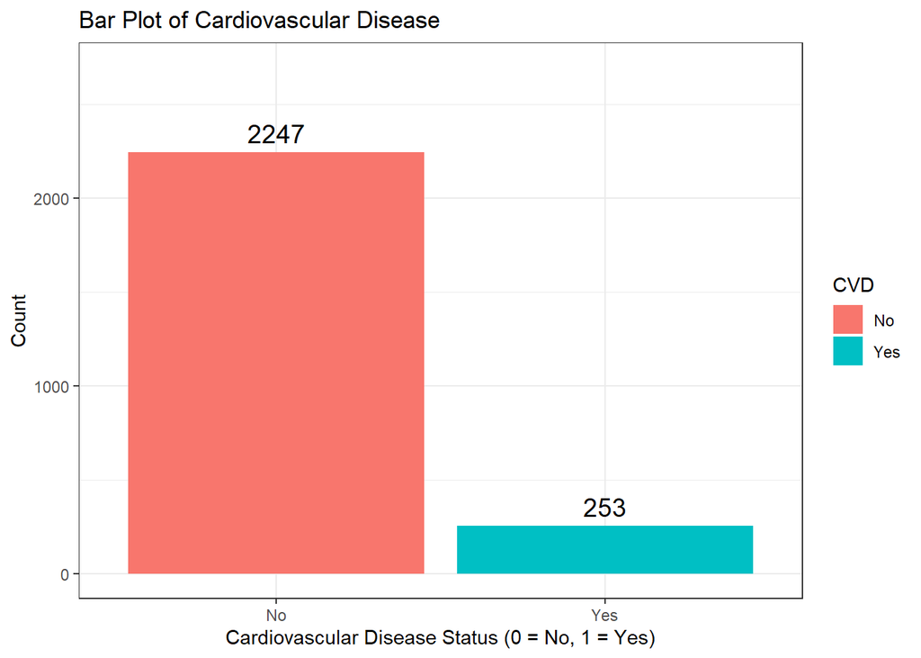

```r
ggplot(pressure, aes(x = CVD, fill = CVD)) +
  geom_bar() +
  geom_text(stat = "count",
            aes(label = after_stat(count)),
            vjust = -0.5, size = 5) +
  labs(title = "Bar Plot of Cardiovascular Disease",
       x = "Cardiovascular Disease Status (0 = No, 1 = Yes)",
       y = "Count") +
  theme_bw() +
  expand_limits(y = max(table(pressure$CVD)) * 1.2)  # ← Extend y-axis by 20%
```

#3.1.5b,visualize ouliers via box plots

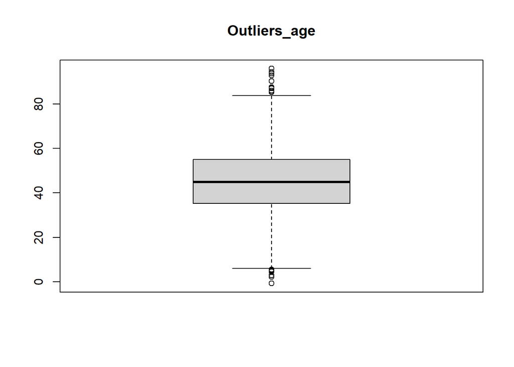

```r
boxplot(pressure$age, main="Outliers_age")
```

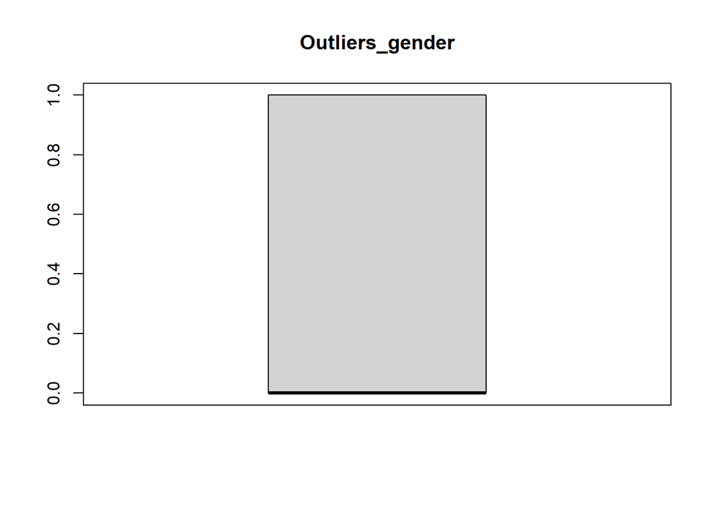

```r
boxplot(pressure$gender, main="Outliers_gender")
```

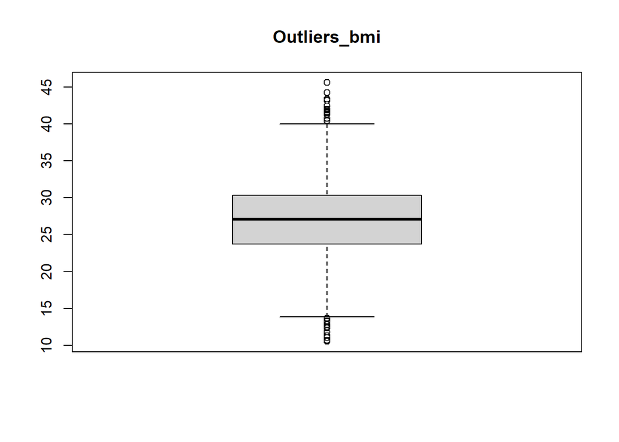

```r
boxplot(pressure$bmi, main="Outliers_bmi")
```

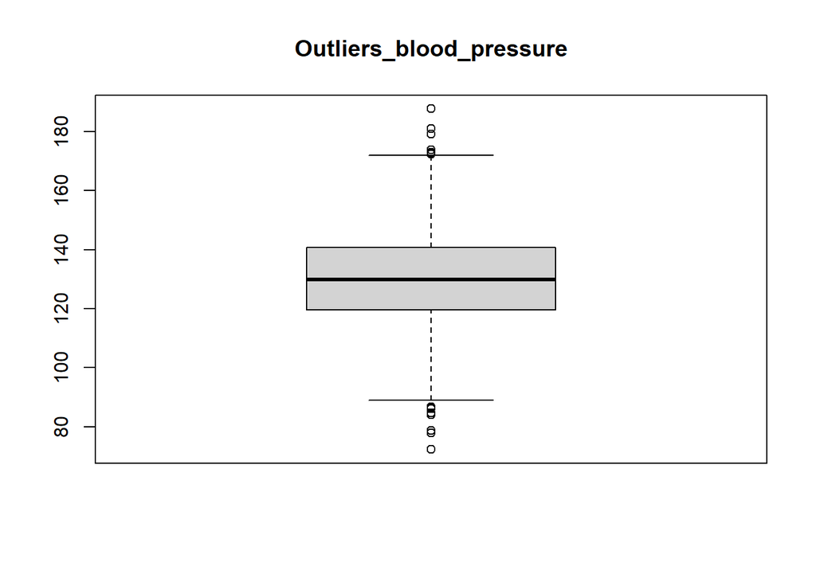

```r
boxplot(pressure$blood_pressure, main="Outliers_blood_pressure")
```

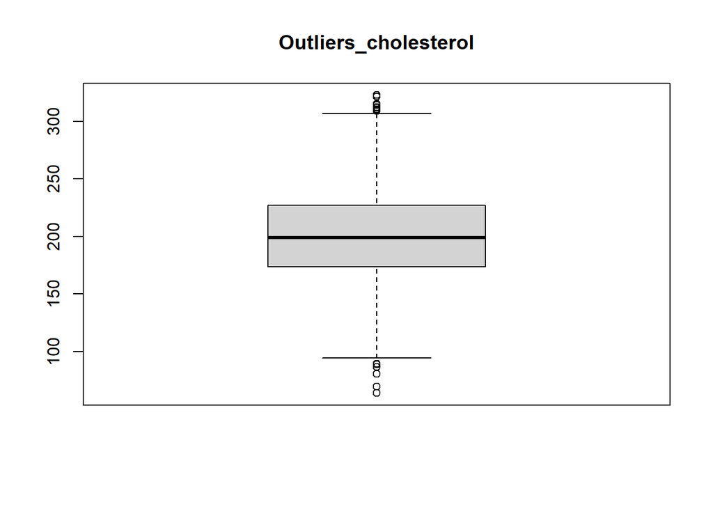

```r
boxplot(pressure$cholesterol, main="Outliers_cholesterol")
```

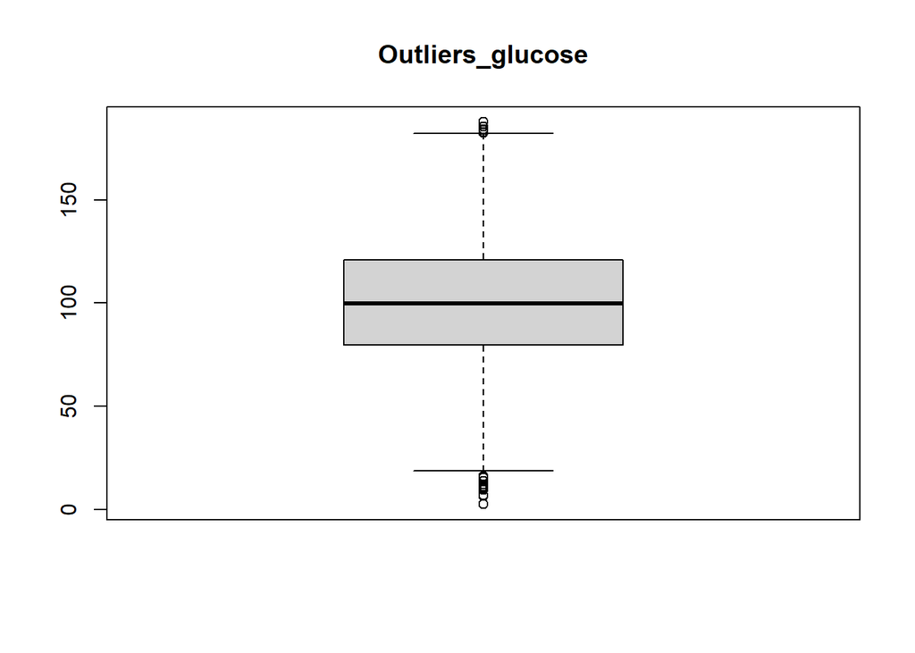

```r
boxplot(pressure$glucose, main="Outliers_glucose")
```

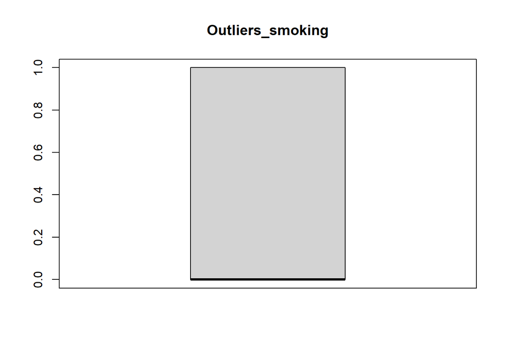

```r
boxplot(pressure$smoking, main="Outliers_smoking")
```

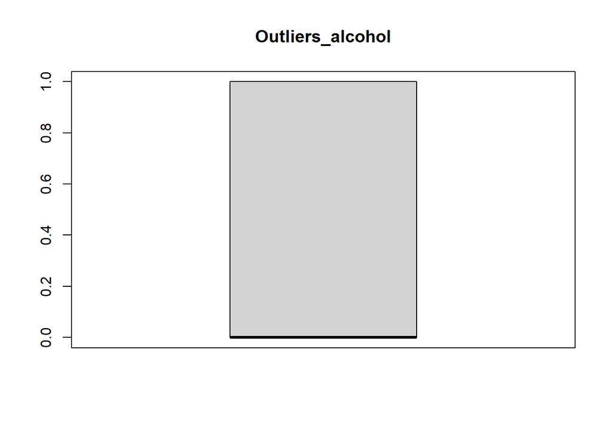

```r
boxplot(pressure$alcohol, main="Outliers_alcohol")
```

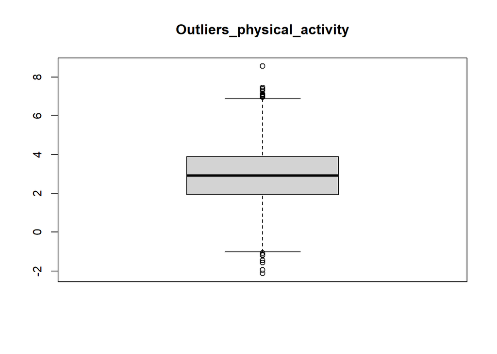

```r
boxplot(pressure$physical_activity, main="Outliers_physical_activity")
```

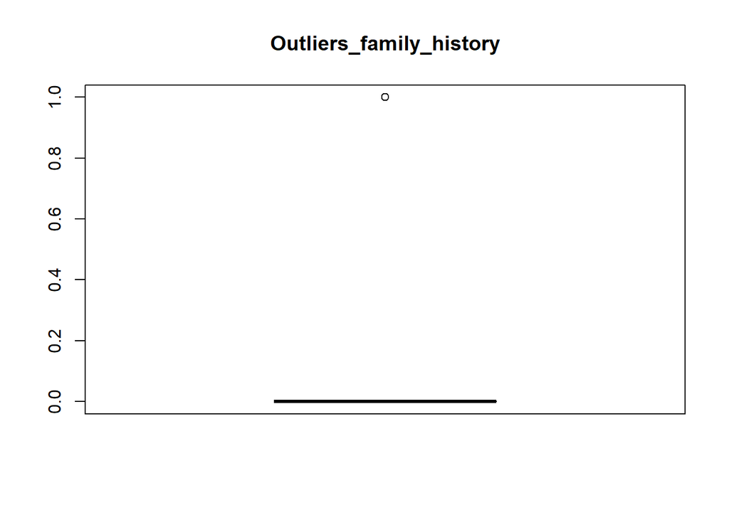

```r
boxplot(pressure$family_history, main="Outliers_family_history")
```

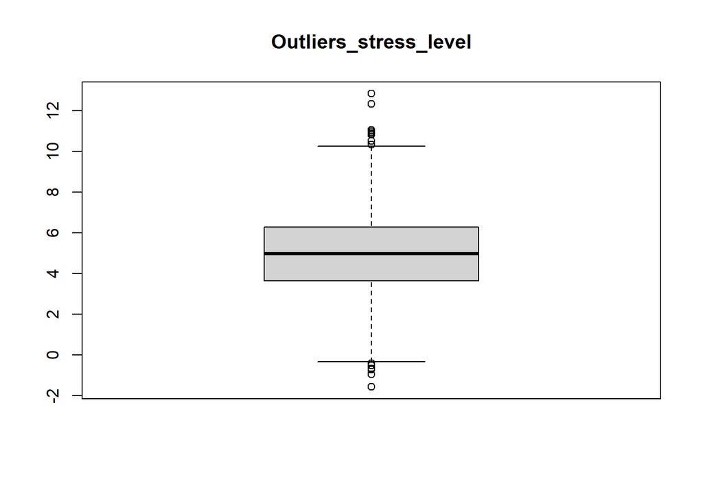

```r
boxplot(pressure$stress_level, main="Outliers_stress_level")
```

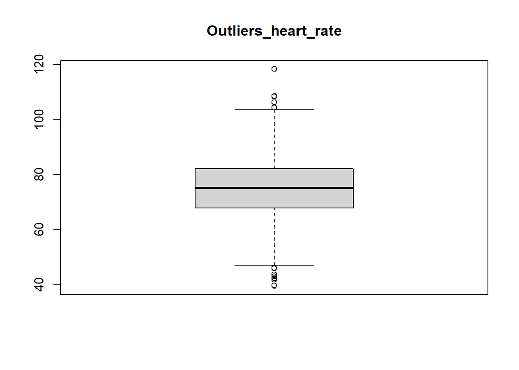

```r
boxplot(pressure$heart_rate, main="Outliers_heart_rate")
```

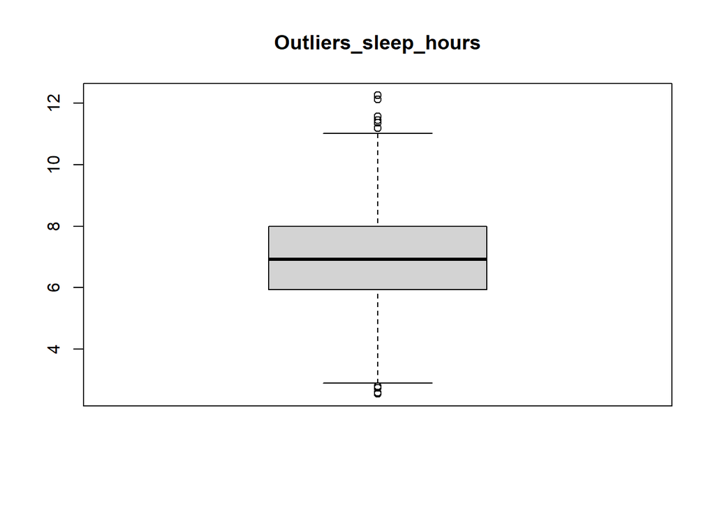

```r
boxplot(pressure$sleep_hours, main="Outliers_sleep_hours")
```

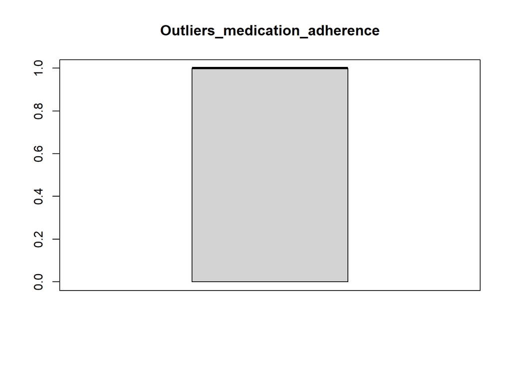

```r
boxplot(pressure$medication_adherence, main="Outliers_medication_adherence")
```

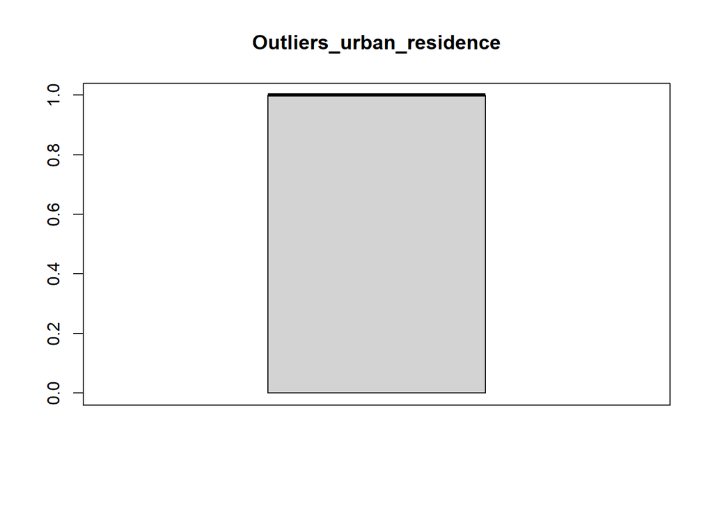

```r
boxplot(pressure$urban_residence, main="Outliers_urban_residence")
```

3.2 Task 2: Data Preprocessing (15 Marks) #3.2.1. Handle missing values (justify your method: removal orimputation).

```r
pressure_clean <- na.omit(pressure)
```

Justification: Complete case analysis to ensure modeltraining uses only verified patient records, training uses only verified patient records. If NA rate >5%, multiple imputation would be preferred in production.

#3.2.2. Convert categorical variables (Gender, Smoking, Alcohol, Exercise, FamilyHistory,Medication) to factors.

```r
categorical_vars <- c("gender", "smoking", "alcohol","physical_activity",
                      "family_history", "medication_adherence")

pressure_clean[categorical_vars] <- lapply(pressure_clean[categorical_vars], as.factor)
```

#3.2.3. Ensure the target variable CVD is a factor with levels “No” (0) and “Yes” (1).

```r
pressure_clean$CVD <- factor(pressure_clean$CVD,
                                 levels = c("No", "Yes"))
```

#3.2.4. Scale numeric predictors (mean = 0, sd = 1) using preProcess() from caret. #3.2.4a) site numerical variables

```r
numeric_vars <- names(pressure_clean)[sapply(pressure_clean, is.numeric)]
numeric_vars
```

```
## [1] "age"             "bmi"             "blood_pressure"  "cholesterol"
## [5] "glucose"         "stress_level"    "heart_rate"      "sleep_hours"
## [9] "urban_residence"
```

3.3 Task 3: Data Partitioning (10 Marks)

#3.3.1. Set the seed to 2026 for reproducibility. #3.3.2. Split the data into 70% training and 30% testing using stratified sampling (to preserve class balance).Note: Fit the scaling parameters on the training data only

```r
# Set seed for reproducibility
set.seed(2026)

#Stratified 70/30 split
train_index <- createDataPartition(pressure_clean$CVD, p = 0.7, list = FALSE)
train_data  <- pressure_clean[train_index, ]
test_data   <- pressure_clean[-train_index, ]

#Scale numeric predictors (fit parameters on TRAINING data ONLY)
preproc_params <- preProcess(train_data[, numeric_vars], method = c("center", "scale"))
train_data[, numeric_vars] <- predict(preproc_params, train_data[, numeric_vars])
test_data[, numeric_vars]  <- predict(preproc_params, test_data[, numeric_vars])
```

#3.2.4c)verify scaling using numerical variable ‘age’

```r
cat("\n========== SCALING VERIFICATION ==========\n")
```

```
##
## ========== SCALING VERIFICATION ==========
```

```r
cat("Original age - Mean:", mean(pressure_clean$age), "| SD:", sd(pressure_clean$age), "\n")
```

```
## Original age - Mean: 45.15943 | SD: 14.83276
```

```r
cat("Training age (scaled) - Mean:", round(mean(train_data$age), 3),
    "| SD:", round(sd(train_data$age), 3), "\n")
```

```
## Training age (scaled) - Mean: 0 | SD: 1
```

```r
cat("Test age (scaled) - Mean:", round(mean(test_data$age), 3),
    "| SD:", round(sd(test_data$age), 3), "\n")
```

```
## Test age (scaled) - Mean: 0.022 | SD: 1.045
```

```r
cat("\nAll scaled variables (training data):\n")
```

```
##
## All scaled variables (training data):
```

```r
print(round(colMeans(train_data[, numeric_vars]), 3))
```

```
##             age             bmi  blood_pressure     cholesterol         glucose
##               0               0               0               0               0
##    stress_level      heart_rate     sleep_hours urban_residence
##               0               0               0               0
```

```r
print(round(apply(train_data[, numeric_vars], 2, sd), 3))
```

```
##             age             bmi  blood_pressure     cholesterol         glucose
##               1               1               1               1               1
##    stress_level      heart_rate     sleep_hours urban_residence
##               1               1               1               1
```

#3.3.3. Report the class distribution in both training and testing sets. #Report the class distribution in both training and testing sets

```r
dim(train_data)
```

```
## [1] 1751   16
```

```r
dim(test_data)
```

```
## [1] 749  16
```

```r
cat("\n--- Training Set Distribution ---\n")
```

```
##
## --- Training Set Distribution ---
```

```r
print(prop.table(table(train_data$CVD)))
```

```
##
##        No       Yes
## 0.8983438 0.1016562
```

```r
cat("\n--- Test Set Distribution ---\n")
```

```
##
## --- Test Set Distribution ---
```

```r
print(prop.table(table(test_data$CVD)))
```

```
##
##        No       Yes
## 0.8998665 0.1001335
```

#3.2.4d. verify split sampling

```r
prop.table(table(train_data$CVD))
```

```
##
##        No       Yes
## 0.8983438 0.1016562
```

```r
prop.table(table(test_data$CVD))
```

```
##
##        No       Yes
## 0.8998665 0.1001335
```

#3.2.4e) Check stratification worked

```r
# Check stratification worked
cat("\nStratification check - CVD proportion:\n")
```

```
##
## Stratification check - CVD proportion:
```

```r
cat("Original:", round(prop.table(table(pressure_clean$CVD))[2] * 100, 1), "%\n")
```

```
## Original: 10.1 %
```

```r
cat("Training:", round(prop.table(table(train_data$CVD))[2] * 100, 1), "%\n")
```

```
## Training: 10.2 %
```

```r
cat("Testing:", round(prop.table(table(test_data$CVD))[2] * 100, 1), "%\n")
```

```
## Testing: 10 %
```

3.4 Task 4: Model Training with trainControl (20 Marks) #3.4.1. Define a trainControl scheme with 10-fold cross-validation.

```r
ctrl <- trainControl(
  method = "cv",
  number = 10,
  classProbs = TRUE,
  summaryFunction = twoClassSummary,
  savePredictions = "final"
)
```

#3.4.2a. Train a Logistic Regression model using caret::train() with method “glm”.

```r
set.seed(2026)

model_lr <- train(
  CVD ~ age + gender + bmi + blood_pressure + cholesterol +
      glucose + smoking + alcohol + family_history + stress_level + sleep_hours + urban_residence,


  data = train_data,                   # Logistic regression
  method = "glm",                     # Binary classification
  trControl = ctrl,
  family = binomial
)
print(model_lr)
```

```
## Generalized Linear Model
##
## 1751 samples
##   12 predictor
##    2 classes: 'No', 'Yes'
##
## No pre-processing
## Resampling: Cross-Validated (10 fold)
## Summary of sample sizes: 1576, 1575, 1576, 1575, 1577, 1576, ...
## Resampling results:
##
##   ROC       Sens      Spec
##   0.835494  0.990466  0.2133987
```

#3.4.2b) summary results

```r
model_lr$results
```

```
##   parameter      ROC     Sens      Spec      ROCSD      SensSD     SpecSD
## 1      none 0.835494 0.990466 0.2133987 0.04814782 0.003344386 0.05065184
```

#3.4.4a. Extract & display coefficients

```r
# Extract coefficients
coef_vec <- coef(model_lr$finalModel)

# Convert to data frame
coef_df <- data.frame(
  Variable = names(coef_vec),
  Coefficient = as.numeric(coef_vec)
)

# Order from largest to smallest
coef_df <- coef_df[order(coef_df$Coefficient, decreasing = TRUE), ]

# Display
cat("\n--- Coefficients (Largest to Smallest) ---\n")
```

```
##
## --- Coefficients (Largest to Smallest) ---
```

```r
print(coef_df)
```

```
##           Variable Coefficient
## 10 family_history1  1.11288827
## 7          glucose  0.72488131
## 8         smoking1  0.67617828
## 11    stress_level  0.60168924
## 6      cholesterol  0.56124779
## 2              age  0.55724360
## 4              bmi  0.42880570
## 3          gender1  0.39429300
## 5   blood_pressure  0.31896201
## 9         alcohol1  0.26133667
## 13 urban_residence -0.03970891
## 12     sleep_hours -0.78766348
## 1      (Intercept) -3.86062833
```

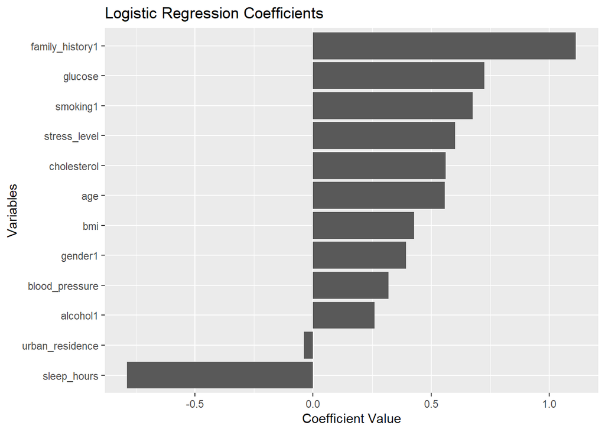

```r
#Extract & prepare
coef_vec <- coef(model_lr$finalModel)
coef_df <- data.frame(
  Variable = names(coef_vec),
  Coefficient = as.numeric(coef_vec)
)

# Remove intercept
coef_df <- subset(coef_df, Variable != "(Intercept)")

# Order by importance
coef_df <- coef_df[order(abs(coef_df$Coefficient), decreasing = TRUE), ]

# Plot
ggplot(coef_df, aes(x = reorder(Variable, Coefficient), y = Coefficient)) +
  geom_bar(stat = "identity") +
  coord_flip() +
  labs(title = "Logistic Regression Coefficients",
       x = "Variables",
       y = "Coefficient Value")
```

#3.4.3. Alternatively, fit a baseline model using base R glm() function.

```r
baseline_model <- glm(
  CVD ~ age + gender + bmi + blood_pressure + cholesterol +
      glucose + smoking + alcohol + family_history + stress_level + sleep_hours + urban_residence,
                      data = train_data, # Training data
                      family = binomial) # Logistic regression

# Display model summary
summary(baseline_model)
```

```
##
## Call:
## glm(formula = CVD ~ age + gender + bmi + blood_pressure + cholesterol +
##     glucose + smoking + alcohol + family_history + stress_level +
##     sleep_hours + urban_residence, family = binomial, data = train_data)
##
## Coefficients:
##                 Estimate Std. Error z value Pr(>|z|)
## (Intercept)     -3.86063    0.22772 -16.953  < 2e-16 ***
## age              0.55724    0.09246   6.027 1.67e-09 ***
## gender1          0.39429    0.18228   2.163 0.030528 *
## bmi              0.42881    0.09248   4.637 3.54e-06 ***
## blood_pressure   0.31896    0.09151   3.485 0.000491 ***
## cholesterol      0.56125    0.09433   5.950 2.68e-09 ***
## glucose          0.72488    0.09926   7.303 2.81e-13 ***
## smoking1         0.67618    0.18829   3.591 0.000329 ***
## alcohol1         0.26134    0.18300   1.428 0.153278
## family_history1  1.11289    0.19026   5.849 4.94e-09 ***
## stress_level     0.60169    0.09363   6.426 1.31e-10 ***
## sleep_hours     -0.78766    0.10023  -7.859 3.88e-15 ***
## urban_residence -0.03971    0.08965  -0.443 0.657816
## ---
## Signif. codes:  0 '***' 0.001 '**' 0.01 '*' 0.05 '.' 0.1 ' ' 1
##
## (Dispersion parameter for binomial family taken to be 1)
##
##     Null deviance: 1151.13  on 1750  degrees of freedom
## Residual deviance:  849.53  on 1738  degrees of freedom
## AIC: 875.53
##
## Number of Fisher Scoring iterations: 6
```

#3.4.4b. Extract and report the model coefficients.

```r
cat("\n--- Model Coefficients ---\n")
```

```
##
## --- Model Coefficients ---
```

```r
print(coef(baseline_model))
```

```
##     (Intercept)             age         gender1             bmi  blood_pressure
##     -3.86062833      0.55724360      0.39429300      0.42880570      0.31896201
##     cholesterol         glucose        smoking1        alcohol1 family_history1
##      0.56124779      0.72488131      0.67617828      0.26133667      1.11288827
##    stress_level     sleep_hours urban_residence
##      0.60168924     -0.78766348     -0.03970891
```

3.5 Task 5: Model Evaluation (25 Marks) #3.5.1. Predict the class and probabilities on the test set.

```r
pred_class <- predict(model_lr, newdata = test_data)
pred_probs <- predict(model_lr, newdata = test_data, type = "prob")

pred_probs
```

[output not shown]

[output cut: 735 more lines]

#3.5.2. Generate a Confusion Matrix and report: •Accuracy•Sensitivity (Recall)•Specificity•Kappa

```r
cm <- confusionMatrix(pred_class, test_data$CVD, positive = "Yes")
cat("\n--- Confusion Matrix Metrics ---\n")
```

```
##
## --- Confusion Matrix Metrics ---
```

```r
cat(sprintf("Accuracy:   %.4f\n", cm$overall["Accuracy"]))
```

```
## Accuracy:   0.8945
```

```r
cat(sprintf("Sensitivity (Recall): %.4f\n", cm$byClass["Sensitivity"]))
```

```
## Sensitivity (Recall): 0.1333
```

```r
cat(sprintf("Specificity: %.4f\n", cm$byClass["Specificity"]))
```

```
## Specificity: 0.9792
```

```r
cat(sprintf("Kappa:      %.4f\n", cm$overall["Kappa"]))
```

```
## Kappa:      0.1613
```

```r
print(cm)
```

```
## Confusion Matrix and Statistics
##
##           Reference
## Prediction  No Yes
##        No  660  65
##        Yes  14  10
##
##                Accuracy : 0.8945
##                  95% CI : (0.8703, 0.9156)
##     No Information Rate : 0.8999
##     P-Value [Acc > NIR] : 0.7119
##
##                   Kappa : 0.1613
##
##  Mcnemar's Test P-Value : 1.85e-08
##
##             Sensitivity : 0.13333
##             Specificity : 0.97923
##          Pos Pred Value : 0.41667
##          Neg Pred Value : 0.91034
##              Prevalence : 0.10013
##          Detection Rate : 0.01335
##    Detection Prevalence : 0.03204
##       Balanced Accuracy : 0.55628
##
##        'Positive' Class : Yes
##
```

#3.5.3. Plot the ROC Curve and calculate the AUC (Area Under Curve).

```r
roc_obj <- roc(test_data$CVD, pred_probs$Yes, levels = c("No", "Yes"), direction = "<")
auc_val <- auc(roc_obj)
cat("\nAUC (Area Under Curve):", round(auc_val, 4), "\n")
```

```
##
## AUC (Area Under Curve): 0.7899
```

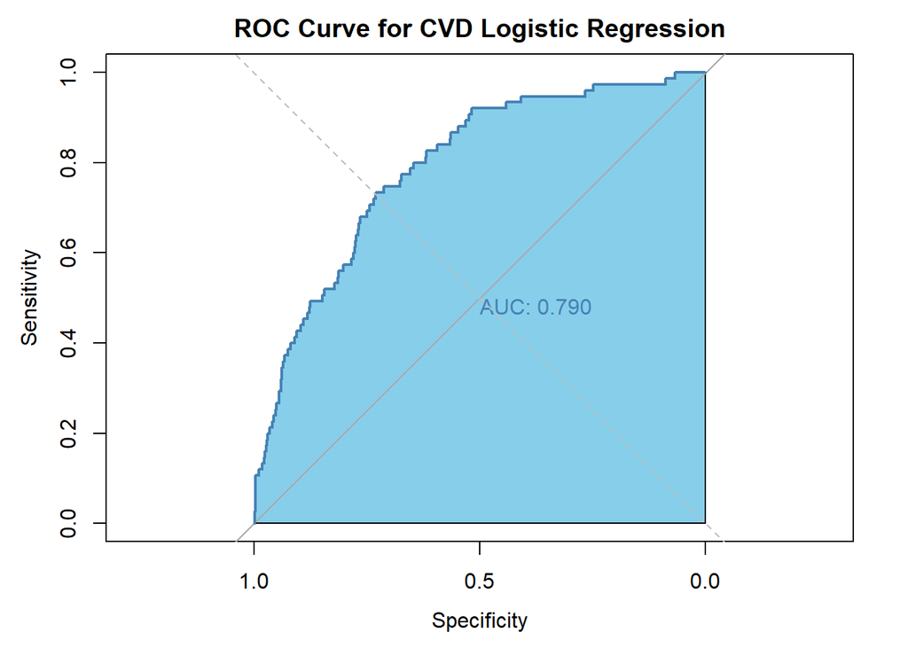

```r
plot(roc_obj, main = "ROC Curve for CVD Logistic Regression",
     col = "steelblue", lwd = 2, print.auc = TRUE, auc.polygon = TRUE,
     auc.polygon.col = "skyblue")
abline(a = 0, b = 1, lty = 2, col = "gray")
```

#3.5.4b Threshold Optimization

```r
thresholds <- seq(0.10, 0.50, by = 0.05)
thresh_results <- data.frame()

for(t in thresholds) {
  pred_t <- factor(ifelse(pred_probs$Yes > t, "Yes", "No"), levels = c("No", "Yes"))
  cm_t   <- confusionMatrix(pred_t, test_data$CVD, positive = "Yes")
  thresh_results <- rbind(thresh_results, data.frame(
    Threshold   = t,
    Sensitivity = cm_t$byClass["Sensitivity"],
    Specificity = cm_t$byClass["Specificity"],
    Accuracy    = cm_t$overall["Accuracy"],
    Kappa       = cm_t$overall["Kappa"]
  ))
}

print(thresh_results)
```

```
##              Threshold Sensitivity Specificity  Accuracy     Kappa
## Sensitivity       0.10   0.7333333   0.7240356 0.7249666 0.2305843
## Sensitivity1      0.15   0.5200000   0.8219585 0.7917223 0.2283246
## Sensitivity2      0.20   0.4800000   0.8753709 0.8357810 0.2805669
## Sensitivity3      0.25   0.4266667   0.9050445 0.8571429 0.2950061
## Sensitivity4      0.30   0.3600000   0.9347181 0.8771696 0.3018723
## Sensitivity5      0.35   0.2533333   0.9495549 0.8798398 0.2332977
## Sensitivity6      0.40   0.2133333   0.9584570 0.8838451 0.2104421
## Sensitivity7      0.45   0.1866667   0.9718101 0.8931909 0.2109768
## Sensitivity8      0.50   0.1333333   0.9792285 0.8945260 0.1613018
```

#3.5.4c. Visualize threshold trade-off

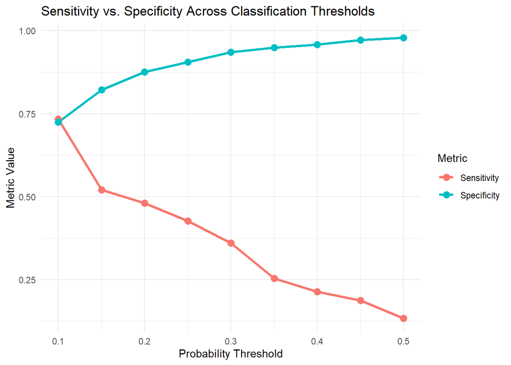

```r
thresh_results %>%
  pivot_longer(cols = c(Sensitivity, Specificity), names_to = "Metric", values_to = "Value") %>%
  ggplot(aes(x = Threshold, y = Value, color = Metric)) +
  geom_line(linewidth = 1.2) +
  geom_point(size = 3) +
  labs(title = "Sensitivity vs. Specificity Across Classification Thresholds",
       x = "Probability Threshold", y = "Metric Value") +
  theme_minimal()
```

3.6 Task 6: Interpretation (20 Marks)

#3.6.2a. Calculate the Odds Ratios (OR) for these predictors (OR = eβ).

```r
# Extract Coefficients, P-values & Odds Ratios
coefs_df <- summary(model_lr$finalModel)$coefficients %>%
  as.data.frame() %>%
  rownames_to_column("Predictor") %>%
  filter(Predictor != "(Intercept)") %>%
  mutate(Odds_Ratio = exp(Estimate)) %>%
  arrange(`Pr(>|z|)`)

print(coefs_df)
```

```
##          Predictor    Estimate Std. Error    z value     Pr(>|z|) Odds_Ratio
## 1      sleep_hours -0.78766348 0.10022789 -7.8587258 3.880608e-15  0.4549065
## 2          glucose  0.72488131 0.09925508  7.3032161 2.809693e-13  2.0644861
## 3     stress_level  0.60168924 0.09362782  6.4263935 1.306669e-10  1.8251994
## 4              age  0.55724360 0.09245919  6.0269142 1.671197e-09  1.7458536
## 5      cholesterol  0.56124779 0.09432851  5.9499273 2.682616e-09  1.7528583
## 6  family_history1  1.11288827 0.19026132  5.8492619 4.937592e-09  3.0431351
## 7              bmi  0.42880570 0.09247879  4.6368003 3.538440e-06  1.5354227
## 8         smoking1  0.67617828 0.18828501  3.5912486 3.290975e-04  1.9663485
## 9   blood_pressure  0.31896201 0.09151494  3.4853544 4.914856e-04  1.3756991
## 10         gender1  0.39429300 0.18227556  2.1631699 3.052811e-02  1.4833351
## 11        alcohol1  0.26133667 0.18300254  1.4280494 1.532776e-01  1.2986648
## 12 urban_residence -0.03970891 0.08965036 -0.4429309 6.578157e-01  0.9610692
```

#3.6.2b. visualize Odds Ratios (OR) for these predictors (OR = eβ).

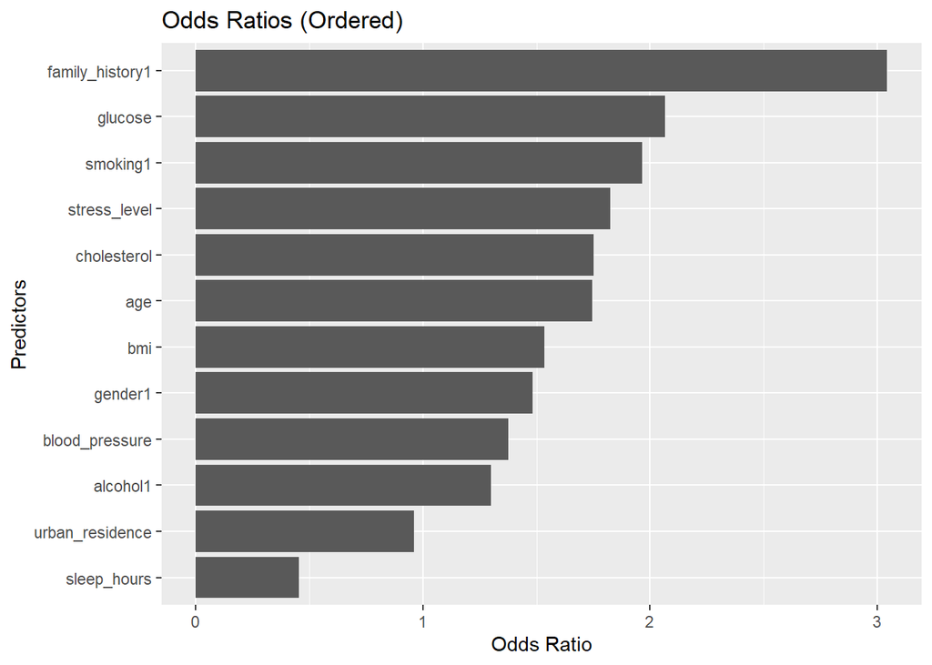

```r
odds_df <- summary(model_lr$finalModel)$coefficients %>%
  as.data.frame() %>%
  rownames_to_column("Predictor") %>%
  filter(Predictor != "(Intercept)") %>%
  mutate(Odds_Ratio = exp(Estimate)) %>%
  select(Predictor, Odds_Ratio) %>%
  arrange(desc(Odds_Ratio))   # largest → smallest


ggplot(odds_df, aes(x = reorder(Predictor, Odds_Ratio), y = Odds_Ratio)) +
  geom_bar(stat = "identity") +
  coord_flip() +
  labs(title = "Odds Ratios (Ordered)",
       x = "Predictors",
       y = "Odds Ratio")
```

#3.6.1a. Select three significant predictors from your model.

```r
top_3 <- coefs_df %>% slice(1:3)
cat("\n--- Top 3 Significant Predictors ---\n")
```

```
##
## --- Top 3 Significant Predictors ---
```

```r
print(top_3)
```

```
##      Predictor   Estimate Std. Error   z value     Pr(>|z|) Odds_Ratio
## 1  sleep_hours -0.7876635 0.10022789 -7.858726 3.880608e-15  0.4549065
## 2      glucose  0.7248813 0.09925508  7.303216 2.809693e-13  2.0644861
## 3 stress_level  0.6016892 0.09362782  6.426393 1.306669e-10  1.8251994
```

#3.6.1b. visualize top predictord of CVD

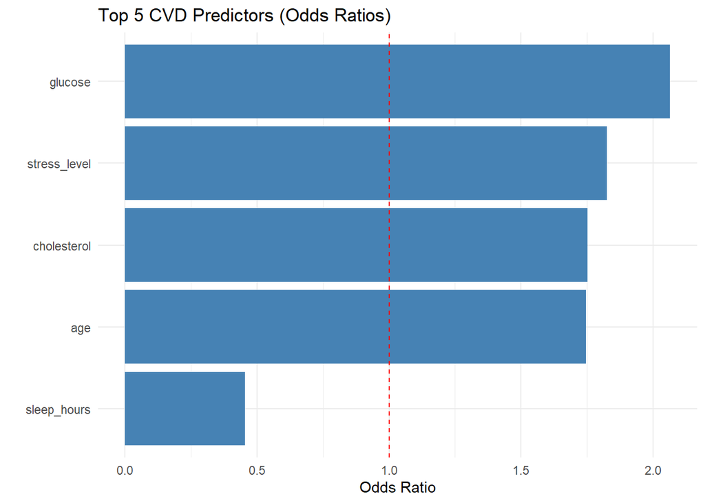

```r
# Extract & prepare odds ratios from your model
top_preds <- summary(model_lr$finalModel)$coefficients %>%
  as.data.frame() %>%
  rownames_to_column("Predictor") %>%
  filter(Predictor != "(Intercept)") %>%
  mutate(OR = exp(Estimate)) %>%
  slice_min(order_by = `Pr(>|z|)`, n = 5)  # Top 5 by p-value

# Simple horizontal bar plot
ggplot(top_preds, aes(x = reorder(Predictor, OR), y = OR)) +
  geom_col(fill = "steelblue") +
  geom_hline(yintercept = 1, linetype = "dashed", color = "red") +
  coord_flip() +
  labs(title = "Top 5 CVD Predictors (Odds Ratios)",
       x = "", y = "Odds Ratio") +
  theme_minimal()
```

#3.6.4. Discuss any limitations of your model(assumptions,potentialbiases) #3.6.4a. Class Imbalance If CVD positive cases are <20%, accuracy can be misleading. Kappa and Sensitivity are more reliable here.

#3.6.4b Linearity Assumption Logistic regression assumes a linear relationship between log-odds and predictors. Non-linear effects (e.g., age vs. CVD risk) may require polynomial terms or splines.

#3.6.4d. Generalizability Model performance depends on the dataset’s demographic and clinical representativeness. External validation is recommended before clinical deployment.

#3.7.1 Correlation Heatmap (Numeric Predictors)

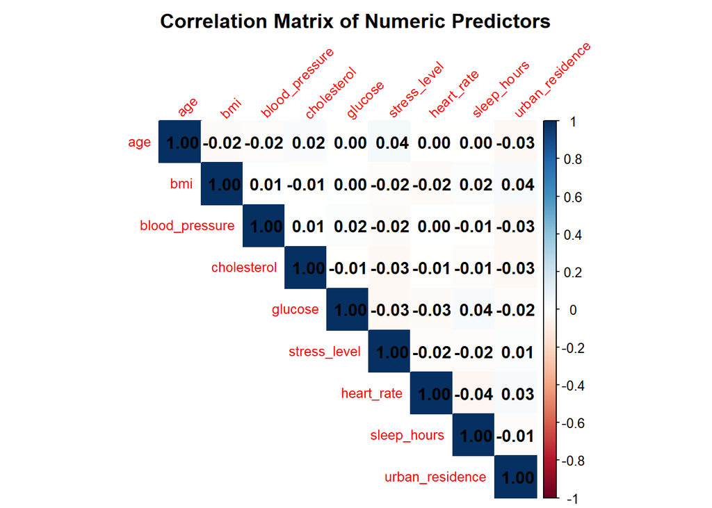

```r
library(corrplot)
numeric_df <- pressure_clean %>% select(where(is.numeric))
cor_mat <- cor(numeric_df, use = "complete.obs")

corrplot(cor_mat, method = "color", type = "upper",
         tl.cex = 0.8, tl.srt = 45, addCoef.col = "black",
         title = "Correlation Matrix of Numeric Predictors", mar = c(0,0,2,0))
```

#3.7.3 Logistic Regression Coefficients (95% CI)

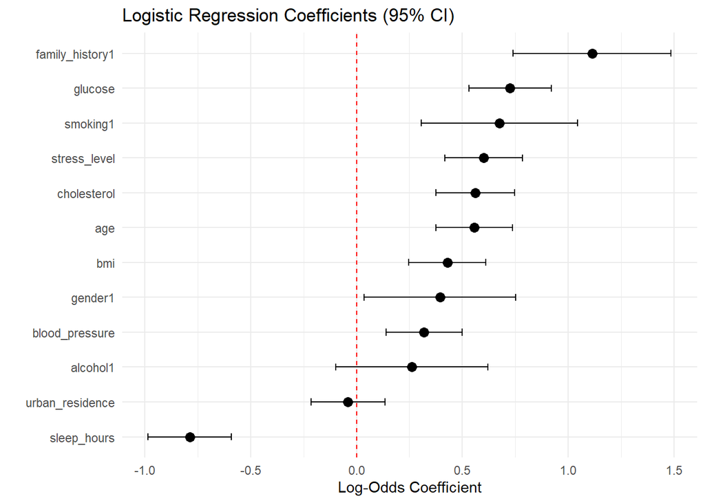

```r
# Extract coefficients + 95% CI
coef_plot <- data.frame(
  Predictor = names(coef(model_lr$finalModel))[-1],  # Remove intercept
  Estimate = coef(model_lr$finalModel)[-1],
  SE = summary(model_lr$finalModel)$coefficients[-1, 2]
) %>%
  mutate(
    Lower = Estimate - 1.96 * SE,
    Upper = Estimate + 1.96 * SE
  ) %>%
  arrange(Estimate)

ggplot(coef_plot, aes(x = reorder(Predictor, Estimate), y = Estimate)) +
  geom_point(size = 3) +
  geom_errorbar(aes(ymin = Lower, ymax = Upper), width = 0.2) +
  geom_hline(yintercept = 0, linetype = "dashed", color = "red") +
  coord_flip() +
  labs(title = "Logistic Regression Coefficients (95% CI)",
       x = "", y = "Log-Odds Coefficient") +
  theme_minimal()
```

#3.7.4 Predictor Importance Ranking (Absolute Coefficients)

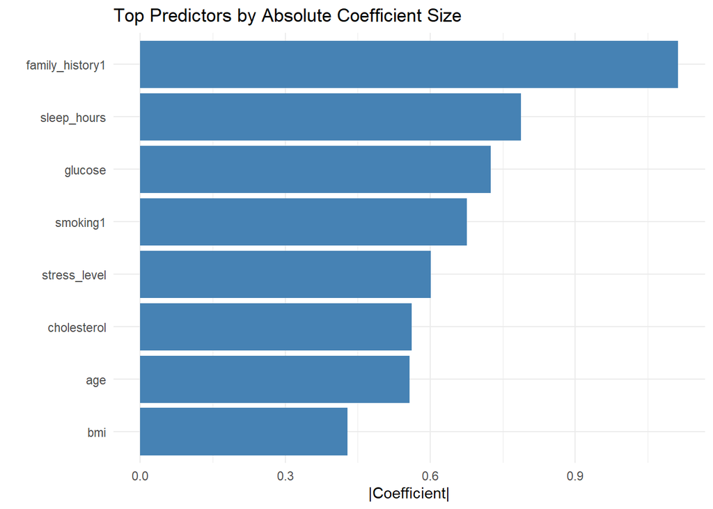

```r
coef_importance <- data.frame(
  Predictor = names(coef(model_lr$finalModel))[-1],
  Abs_Coef = abs(coef(model_lr$finalModel)[-1])
) %>%
  arrange(desc(Abs_Coef)) %>%
  slice(1:8)  # Top 8

ggplot(coef_importance, aes(x = reorder(Predictor, Abs_Coef), y = Abs_Coef)) +
  geom_col(fill = "steelblue") +
  coord_flip() +
  labs(title = "Top Predictors by Absolute Coefficient Size",
       x = "", y = "|Coefficient|") +
  theme_minimal()
```